# Assignment 2 - The backdoor criterion, regression, and matching

GIORGIO COPPOLA

March 17, 2023 | 11:56:37 | CET

**General rules:**

- Make sure to knit your Rmd regularly to catch bugs early. You’ll have to submit the solution as HTML, not Rmd.
- You should clearly indicate what you submit as your solution for every single task. The code that produces a solution is not sufficient - we want to see the output too. If not indicated otherwise, the output in the console is sufficient, which means that you don’t have to add a sentence like “The ATE is 3.5.”.
- Figures need meaningful descriptions. Axes need meaningful labels. The use of colors serves a purpose. Tables need meaningful headers.
- For any numeric result you print, do not report more than 2 decimal points. This means that you regularly have to apply rounding.
- Every task deserves its own space. Your comments and explanations should be clearly distinguishable from other content of your script.
- Your solution sheet should be straightforward to read. We should not have to actively search for the solutions. Don’t print entire datasets or hundreds of observations.

### Task 1 - Closing backdoors in a DAG [4 points in total]

After months of research, you decide that your thesis will focus on the relationship between groundbreaking policy $X$ and societally relevant outcome $Y$. In preparation for the meeting with your supervisor, you read all the relevant literature, conduct interviews, and finally write down a directed acyclic graph. You believe this graph captures all of the relevant variables and their relationships (see figure below). You proudly present the DAG below to your supervisor.

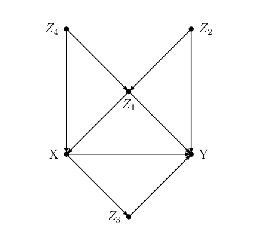

1. **Reproduce the DAG with R! The absolute position of the nodes is irrelevant, but all relationships should match those depicted in the original DAG. [1 point]**

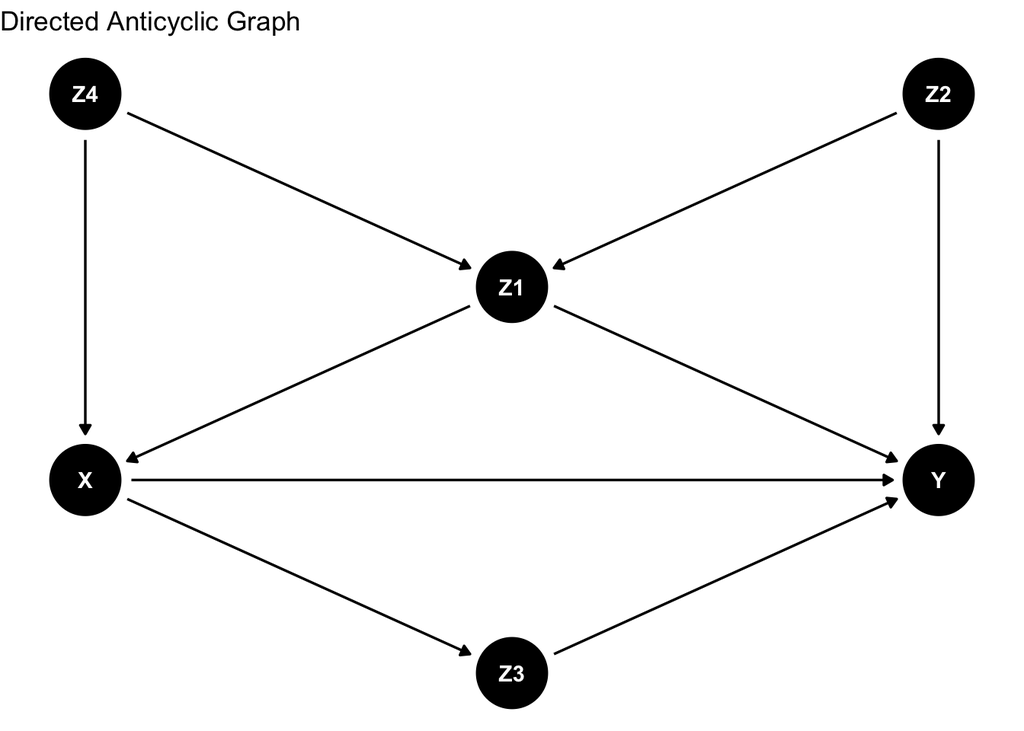

```r
# Put your code here
c_dag <- list(
  x = c(Z4 = -1, X = -1, Z2 = 1, Y = 1, Z1 = 0, Z3 = 0),
  y = c(Z4 = 3, X = 1, Z2 = 3, Y = 1, Z1 = 2, Z3 = 0))

dag_thesis <- ggdag::dagify(X ~ Z4,
                         Z1 ~ Z4,
                         Z1 ~ Z2,
                         Y ~ Z2,
                         Y ~ Z1,
                         X ~ Z1,
                         Z3 ~ X,
                         Y ~ Z3,
                         Y ~ X,
                         coords = c_dag,
                         exposure = "X",
                         outcome = "Y")


ggdag::ggdag(dag_thesis) +
  theme_void() +
  ggtitle("Directed Anticyclic Graph")
```

2. **For your DAG, write down all paths from X to Y. Which paths are causal? [1 point]**

```r
# Put your code here
dagitty::paths(dag_thesis)
```

```
$paths
[1] "X -> Y"                   "X -> Z3 -> Y"
[3] "X <- Z1 -> Y"             "X <- Z1 <- Z2 -> Y"
[5] "X <- Z4 -> Z1 -> Y"       "X <- Z4 -> Z1 <- Z2 -> Y"

$open
[1]  TRUE  TRUE  TRUE  TRUE  TRUE FALSE
```

Put your answer here:

The causal path are X –> Y and X –> Z3 –> Y. The non-causal backdoor paths are X <– Z1 –> Y (open), X <– Z4 –> Z1 –> Y (open), X <– Z1 <- Z2 –> Y (open), and X <– Z4 –> Z1 <– Z2 –> Y (closed).

3. **In the path** $X$ ← $Z_4$ → $Z_1$ ← $Z_2$ → $Y$, what type of node is $Z_1$? Does conditioning on $Z_1$ block or unblock this path from X to $Y$? Briefly explain your answer. [0.5 points]

Put your answer here:

Z1 is a collider. Colliders naturally block the path between X and Y. Therefore, conditioning for Z1 would unlock this path, creating a collider bias, inducing a relationship between X and Y, even though the relationship is not actually present in the full population.

3. **Now consider the path** $X$ ← $Z_1$ → $Y$. Does conditioning on $Z_1$ block or unblock this path? Briefly explain your answer. [0.5 points]

Put your answer here:

Z1 in this case is a confounder. Confounders does not naturally block the path between X and Y. Conditioning for a confounder indeed blocks the path. We need to condition for a confounder to avoid OVB correctly identify the causal relation between X and Y.

4. **Based on your DAG, list the minimum sets of variables to condition on that satisfy the backdoor criterion for identifying the effect of** $X$ on $Y$. [1 point]

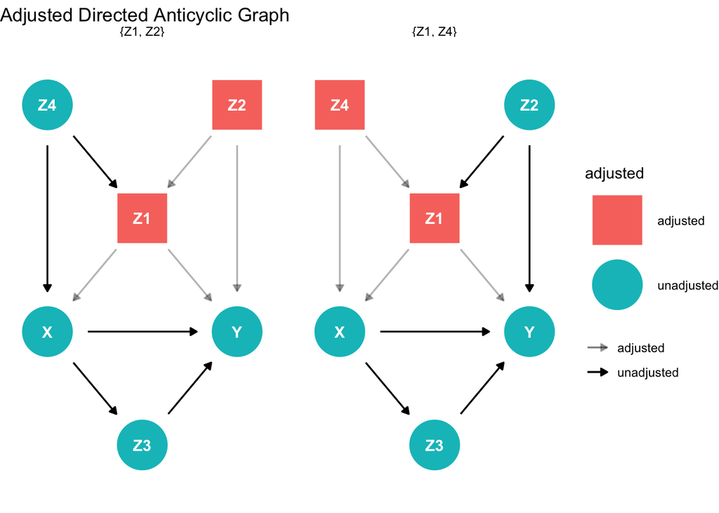

```r
# Put your code here
ggdag::ggdag_adjustment_set(dag_thesis, shadow = T) +
  theme_void() + ggtitle("Adjusted Directed Anticyclic Graph")
```

Put your answer here:

The variables we should condition for is Z1, as it is a confounder of the relation between X and Y. However, Z1 is also a collider in the relationship between Z4 and Z2. By controlling for Z1, we will open a path that should remain closed, inducing a relation between Z2 and Z4. To avoid this condition, we should also control for either Z2 or Z4.

### Task 2 - Smoking behavior and infant birth weight [7 points in total]

For this exercise, you will use the `bwght` dataset from the `wooldridge` package. The data comes from the 1988 US National Health Interview Survey and contains information of maternal smoking behavior, infant birth weight, and additional social and economic markers. *Note:* The `bwght` dataset is already loaded in the first R chunk of this file (`pacman::p_load()`. To see what additional information is in the dataset, you can type `?bwght` in your R console.

1. **Estimate the following model:** $\text{bwght} = \beta_0 + \beta_1\text{cigs} + \beta_2\text{male}$ and report the estimated model as an HTML table. Then, use R to predict the estimated birth weight in kilograms for a baby girl with a mother that smoked 20 cigarettes per day while pregnant. [2 points]

```r
# Put your code here
# Creating the model and the table:
model <- lm(bwght ~ cigs + male, data = bwght)

model_table <- stargazer::stargazer(model, type = "html",
                dep.var.labels = "Birth weight, ounces",
                covariate.labels = c("Cigs per day while pregnant", "Male child"),
                title = "Effects of Smoking on Birth Weight by Baby's Gender",
                digits = 2)
```

**Effects of Smoking on Birth Weight by Baby’s Gender**

|  | *Dependent variable:* |
| --- | --- |
|  | Birth weight, ounces |
| Cigs per day while pregnant | -0.51*** |
|  | (0.09) |
| Male child | 2.94*** |
|  | (1.08) |
| Constant | 118.24*** |
|  | (0.80) |
| Observations | 1,388 |
| R<sup>2</sup> | 0.03 |
| Adjusted R<sup>2</sup> | 0.03 |
| Residual Std. Error | 20.08 (df = 1385) |
| F Statistic | 19.90*** (df = 2; 1385) |
| *Note:* | p<0.1; p<0.05; p<0.01 |

```r
# Prediction of a female baby's weight with a mother
# smoking 20 cigarettes per day while pregnant:
round(predict(model, newdata = data.frame(cigs = 20, male = 0))*0.02835, 2)
```

```
   1
3.06
```

2. **Create a new dummy variable, smoker, that takes value 1 if** $cigs > 0$, otherwise 0, and report the proportion of smokers in the sample. Check the balance (smokers vs. non-smokers) on variables in the dataset that could serve as covariates. Your output should be in a well-formatted HTML table. [1 point]

```r
# Put your code here
# Creating the dummy variable:
bwght <- bwght %>%
mutate(smoker = ifelse(cigs == 0, 0, 1))

# Proportion of smokers in the sample:
round(mean(bwght$smoker == 1), 4)
```

```
[1] 0.1527
```

Put your answer here:

The proportion of the smokers in sample is of 15.27%.

```r
# Creating a balance table of the variable in the sample for the control
# (Smoker = 0) and treatment (Smoker = 1) groups:
list_cov <- c("cigtax", "faminc", "fatheduc", "motheduc", "parity")

table2b <- bwght %>%
            dplyr::summarize_at(list_cov, funs(list(broom::tidy(t.test(. ~ smoker))))) %>%
            purrr::map(1) %>%
            dplyr::bind_rows(.id='variables') %>%
            dplyr::select(variables, estimate1, estimate2, p.value) %>%
            dplyr::mutate_if(is.numeric, round, 2) %>%
            knitr::kable(col.names = c("Variable", "Control (Smoker = 0)",
                                       "Treat (Smoker = 1)", "P value")) %>%
            kableExtra::kable_classic_2(bootstrap_options = "striped", full_width = F)

table2b
```

| Variable | Control (Smoker = 0) | Treat (Smoker = 1) | P value |
| --- | --- | --- | --- |
| cigtax | 19.41 | 20.37 | 0.08 |
| faminc | 30.49 | 20.92 | 0.00 |
| fatheduc | 13.39 | 11.89 | 0.00 |
| motheduc | 13.17 | 11.64 | 0.00 |
| parity | 1.62 | 1.72 | 0.11 |

3. **Specify a logit model to generate the propensity scores using variables you would want to match on based on your findings in b). Present the output of the model as a well-formatted HTML table, and provide a well-designed plot that compares the density distribution of the propensity scores for the treated (smoker) and untreated units (non-smoker) before matching, in one panel. [2 points]**

```r
# Put your code here
# Specification of the logit model
model_ps <- glm(smoker ~ faminc + motheduc + fatheduc,
            family = binomial(link = "logit"),
            data = bwght)

# Logit model output table"
model_ps_table <- stargazer::stargazer(model_ps, type ="html",
                  dep.var.labels = "Smoking Status (Smoker = 1)",
                  covariate.labels = c("Family income (in $1000s)",
                       "Mother's education (in years)",
                       "Father's education (in years)"),
                  title = "Logit Model of Smoking Status")
```

**Logit Model of Smoking Status**

|  | *Dependent variable:* |
| --- | --- |
|  | Smoking Status (Smoker = 1) |
| Family income (in 1000s) | -0.015** |
|  | (0.006) |
| Mother’s education (in years) | -0.224*** |
|  | (0.048) |
| Father’s education (in years) | -0.046 |
|  | (0.041) |
| Constant | 1.966*** |
|  | (0.502) |
| Observations | 1,191 |
| Log Likelihood | -434.253 |
| Akaike Inf. Crit. | 876.505 |
| *Note:* | p<0.1; p<0.05; p<0.01 |

Among the pre-selected variables, I have only selected those that are statistically significant.

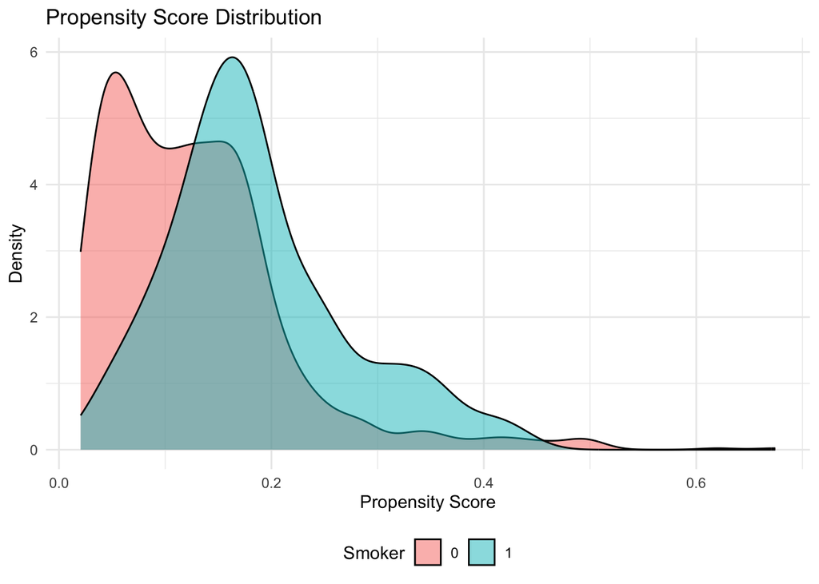

```r
# Creating the propensity score distribution
ps_bwght <- dplyr::tibble(pr_score = predict(model_ps, type = "response"),
                          smoker = model_ps$model$smoker) %>%
                          arrange(pr_score) %>%
                          arrange(desc(smoker))

# Creating the plot that compares the density distribution of the propensity
# scores for the treated (smoker) and untreated units (non-smoker) before matching:
ps_bwght_plot <- ggplot(ps_bwght, aes(x = pr_score, fill = factor(smoker))) +
                 geom_density(alpha = 0.5) +
                 theme_minimal() +
                 theme(legend.position = "bottom") +
                 labs(title = "Propensity Score Distribution",
                 x = "Propensity Score",
                 y = "Density",
                 fill = "Smoker")

ps_bwght_plot
```

```r
# Put your code here
# Omitting the NAs:
bwght_2 <- bwght %>%
           dplyr::select(smoker, faminc, fatheduc, motheduc, bwght) %>%
           na.omit()

# Creating the matched sample:
one_match <- MatchIt::matchit(smoker ~ faminc + motheduc + fatheduc,
                              method = "nearest",
                              ratio = 2,
                              replace = TRUE,
                              data = bwght_2)

# Creating the balance table:
data_prop_match <- MatchIt::get_matches(one_match)

list_cov <- c("faminc", "motheduc", "fatheduc")

data_prop_match_table <- data_prop_match %>%
                          dplyr::summarize_at(list_cov, ~list(broom::tidy(t.test(. ~ smoker)))) %>%
                          purrr::map(1) %>%
                          dplyr::bind_rows(.id='variables') %>%
                          dplyr::select(variables, estimate1, estimate2, p.value) %>%
                          dplyr::mutate_if(is.numeric, round, 2) %>%
                          knitr::kable(col.names = c("Variable", "Control (Smoker = 0)", "Treat (Smoker = 1)", "P value")) %>%
                          kableExtra::kable_classic_2(full_width = F)

data_prop_match_table
```

| Variable | Control (Smoker = 0) | Treat (Smoker = 1) | P value |
| --- | --- | --- | --- |
| faminc | 24.47 | 24.88 | 0.77 |
| motheduc | 11.74 | 11.70 | 0.84 |
| fatheduc | 11.85 | 11.89 | 0.86 |

```r
# Creating the regression table:
prop_match_model <- lm(bwght ~ smoker, data = data_prop_match)

prop_match_reg <- stargazer::stargazer(prop_match_model, type="html",
                    dep.var.labels = "Birth weight in ounces",
                    covariate.labels = c("Smoking Status (Smoker = 1)"),
                    title = "Effect of Being a Smoker on Baby Birth Weight",
                    digits = 2)
```

**Effect of Being a Smoker on Baby Birth Weight**

|  | *Dependent variable:* |
| --- | --- |
|  | Birth weight in ounces |
| Smoking Status (Smoker = 1) | -11.27*** |
|  | (1.72) |
| Constant | 122.75*** |
|  | (0.99) |
| Observations | 483 |
| R<sup>2</sup> | 0.08 |
| Adjusted R<sup>2</sup> | 0.08 |
| Residual Std. Error | 17.83 (df = 481) |
| F Statistic | 42.87*** (df = 1; 481) |
| *Note:* | p<0.1; p<0.05; p<0.01 |

Based on our propensity score, the matched data and our regression, being a being a smoker during pregnancy, on average, reduces the baby birth weight of more than 11 ounces (11.27 ounces). In kg, the baby’s birth weight is reduced of more than 300 g (11.27*0.02835 = 0.319 kg).